[figure not shown]

EN(STI)(diag)-49

Drive Cycle

ENGINE (DIAGNOSTICS)

12.Drive Cycle

A: PROCEDURE

It is necessary to perform the drive cycle listed below if DTC is not found in the Inspection Mode. It is possible

to complete diagnosis of the DTC by performing the indicated drive cycle. After the repair for the DTC, per-

1. PREPARATION FOR DRIVE CYCLE

1) Check that the battery voltage is 12 V or more and fuel remains approx. half [20 — 40 L (5.3 — 10.6 US gal,

4.4 — 8.8 Imp gal)].

2) After performing the diagnostics and Clear Memory Mode, check that no DTC remains. <Ref. to

EN(STI)(diag)-59, Clear Memory Mode.>

3) Make sure that the delivery mode fuse is removed.

NOTE:

Perform the drive cycle after warming up the engine except when the engine coolant temperature at engine

start is specified.

2. DRIVE CYCLE A

Diagnostic procedure:

1) Drive for 20 minutes or more at a constant speed of 80 km/h (50 MPH) or more.

2) Stop the vehicle and idle for one minute.

3) Read the temporary code using the Subaru Select Monitor or general scan tool. <Ref. to EN(STI)(diag)-

42, OPERATION, Read Diagnostic Trouble Code (DTC).>

DTC Item Condition

P0128

Coolant Thermostat (Engine Coolant Temperature Below Thermostat Regulating

Temperature)

—

P0141 O2 Sensor Heater Circuit (Bank1 Sensor2) —

P014C O2 Sensor Slow Response - Rich to Lean (Bank 1 Sensor 1) —

P014D O2 Sensor Slow Response - Lean to Rich (Bank 1 Sensor 1) —

P015A O2 Sensor Delayed Response - Rich to Lean (Bank 1 Sensor 1) —

P015B O2 Sensor Delayed Response - Lean to Rich (Bank 1 Sensor 1) —

P0171 System Too Lean (Bank 1)

Complete diagnosis with drive

cycle B or C as well.

P0172 System Too Rich (Bank 1)

Complete diagnosis with drive

cycle B or C as well.

P0300 Random/Multiple Cylinder Misfire Detected

Complete diagnosis with drive

cycle B or C as well.

P0301 Cylinder 1 Misfire Detected

Complete diagnosis with drive

cycle B or C as well.

P0302 Cylinder 2 Misfire Detected

Complete diagnosis with drive

cycle B or C as well.

P0303 Cylinder 3 Misfire Detected

Complete diagnosis with drive

cycle B or C as well.

P0304 Cylinder 4 Misfire Detected

Complete diagnosis with drive

cycle B or C as well.

P0420 Catalyst System Efficiency Below Threshold (Bank 1) —

P0459 Evaporative Emission System Purge Control Valve Circuit High —

P2096 Post Catalyst Fuel Trim System Too Lean (Bank 1)

Complete diagnosis with drive

cycle B or C as well.

P2097 Post Catalyst Fuel Trim System Too Rich (Bank 1)

Complete diagnosis with drive

cycle B or C as well.

P2195 O2 Sensor Signal Biased/Stuck Lean (Bank 1 Sensor 1) —

P2196 O2 Sensor Signal Biased/Stuck Rich (Bank 1 Sensor 1) —

[figure not shown]

EN(STI)(diag)-50

Drive Cycle

ENGINE (DIAGNOSTICS)

3. DRIVE CYCLE B

Diagnostic procedure:

1) Drive at 10 km/h (6 MPH) or more.

2) Stop the vehicle and idle for ten minutes.

3) Read the temporary code using the Subaru Select Monitor or general scan tool. <Ref. to EN(STI)(diag)-

42, OPERATION, Read Diagnostic Trouble Code (DTC).>

DTC Item Condition

P0125 Insufficient Coolant Temperature for Closed Loop Fuel Control

P0137 O2 Sensor Circuit Low Voltage (Bank 1 Sensor 2) —

P0138 O2 Sensor Circuit High Voltage (Bank 1 Sensor 2) —

P0171 System Too Lean (Bank 1)

Complete diagnosis with drive

cycle A or C as well.

P0172 System Too Rich (Bank 1)

Complete diagnosis with drive

cycle A or C as well.

P0300 Random/Multiple Cylinder Misfire Detected

Complete diagnosis with drive

cycle A or C as well.

P0301 Cylinder 1 Misfire Detected

Complete diagnosis with drive

cycle A or C as well.

P0302 Cylinder 2 Misfire Detected

Complete diagnosis with drive

cycle A or C as well.

P0303 Cylinder 3 Misfire Detected

Complete diagnosis with drive

cycle A or C as well.

P0304 Cylinder 4 Misfire Detected

Complete diagnosis with drive

cycle A or C as well.

P0500 Vehicle Speed Sensor “A” —

P0506 Idle Air Control System RPM Lower Than Expected —

P0507 Idle Air Control System RPM Higher Than Expected —

P2006 Intake Manifold Runner Control Stuck Closed (Bank 1) —

P2007 Intake Manifold Runner Control Stuck Closed (Bank 2) —

P2096 Post Catalyst Fuel Trim System Too Lean (Bank 1)

Complete diagnosis with drive

cycle A or C as well.

P2097 Post Catalyst Fuel Trim System Too Rich (Bank 1)

Complete diagnosis with drive

cycle A or C as well.

P2158 Vehicle Speed Sensor "B" —

P219A Bank 1 Air-Fuel Ratio Imbalance

Complete diagnosis with drive

cycle C as well.

[figure not shown]

EN(STI)(diag)-51

Drive Cycle

ENGINE (DIAGNOSTICS)

4. DRIVE CYCLE C

DTC Item Condition

P000A A Camshaft Position Slow Response (Bank 1) —

P000B B Camshaft Position Slow Response (Bank 1) —

P000C A Camshaft Position Slow Response (Bank 2) —

P000D B Camshaft Position Slow Response (Bank 2) —

P0011

Intake Camshaft Position - Timing Over-Advanced or System Performance

(Bank 1)

—

P0014 Exhaust AVCS System 1 (Range/Performance) —

P0021

Intake Camshaft Position - Timing Over-Advanced or System Performance

(Bank 2)

—

P0024 Exhaust AVCS System 2 (Range/Performance) —

P0030 HO2S Heater Control Circuit (Bank 1 Sensor 1) —

P0068 MAP/MAF - Throttle Position Correlation —

P0101 Mass or Volume Air Flow Circuit Range/Performance —

P0134 O2 Sensor Circuit No Activity Detected (Bank 1 Sensor 1) —

P013A O2 Sensor Slow Response - Rich to Lean (Bank 1 Sensor 2) —

P013B O2 Sensor Slow Response - Lean to Rich (Bank 1 Sensor 2) —

P013E O2 Sensor Delayed Response - Rich to Lean (Bank 1 Sensor 2) —

P013F O2 Sensor Delayed Response - Lean to Rich (Bank 1 Sensor 2) —

P0171 System Too Lean (Bank 1)

Complete diagnosis with drive

cycle A or B as well.

P0172 System Too Rich (Bank 1)

Complete diagnosis with drive

cycle A or B as well.

P0244 Turbo/Super Charger Wastegate Solenoid “A” Range/Performance —

P0246 Turbo/Super Charger Wastegate Solenoid “A” High —

P0300 Random/Multiple Cylinder Misfire Detected

Complete diagnosis with drive

cycle A or B as well.

P0301 Cylinder 1 Misfire Detected

Complete diagnosis with drive

cycle A or B as well.

P0302 Cylinder 2 Misfire Detected

Complete diagnosis with drive

cycle A or B as well.

P0303 Cylinder 3 Misfire Detected

Complete diagnosis with drive

cycle A or B as well.

P0304 Cylinder 4 Misfire Detected

Complete diagnosis with drive

cycle A or B as well.

P0441 Evaporative Emission Cont. Sys. Incorrect Purge Flow —

P04AD Evap System Purge Control Valve "B" Circuit High —

P0851 Park/Neutral Switch Input Circuit Low —

P0852 Park/Neutral Switch Input Circuit High —

P1449 Evaporative Emission Cont. Sys. Air Filter Clog —

P2004 Intake Manifold Runner Control Stuck Open (Bank 1) —

P2005 Intake Manifold Runner Control Stuck Open (Bank 2) —

P2096 Post Catalyst Fuel Trim System Too Lean (Bank 1)

Complete diagnosis with drive

cycle A or B as well.

P2097 Post Catalyst Fuel Trim System Too Rich (Bank 1)

Complete diagnosis with drive

cycle A or B as well.

P219A Bank 1 Air-Fuel Ratio Imbalance

Complete diagnosis with drive

cycle B as well.

P2270 O2 Sensor Signal Biased/Stuck Lean (Bank 1 Sensor 2) —

P2271 O2 Sensor Signal Biased/Stuck Rich (Bank 1 Sensor 2) —

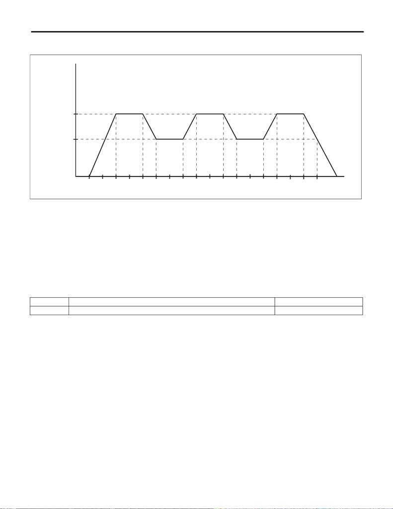

EN(STI)(diag)-52

Drive Cycle

ENGINE (DIAGNOSTICS)

Diagnostic procedure:

1) Drive according to the drive pattern described below.

2) Read the temporary code using the Subaru Select Monitor or general scan tool. <Ref. to EN(STI)(diag)-

42, OPERATION, Read Diagnostic Trouble Code (DTC).>

5. DRIVE CYCLE E

Diagnostic procedure:

1) Make sure that the battery voltage is 10.9 V or more.

2) Perform the Clear Memory Mode. <Ref. to EN(STI)(diag)-59, Clear Memory Mode.>

3) Drive for approximately 30 L (7.9 US gal, 6.6 Imp gal) of fuel.

NOTE:

• It is acceptable to drive the vehicle intermittently.

• Do not disconnect the battery terminals while diagnosing. (Data will be cleared by disconnecting the bat-

tery terminals.)

4) Read the temporary code using the Subaru Select Monitor or general scan tool. <Ref. to EN(STI)(diag)-

42, OPERATION, Read Diagnostic Trouble Code (DTC).>

(A) Place the shift lever in neutral

position, and let the engine idle for

10 seconds or more.

(D) Decelerate with fully closed throt-

tle to 64 km/h (40 MPH) or less.

(G) Stop the vehicle with throttle fully

closed.

(B) Accelerate to 97 km/h (60 MPH)

or more within 20 seconds.

(E) Drive for 20 seconds or more at 64

km/h (40 MPH) or less.

(H) Vehicle speed km/h (MPH)

(C) Drive for 20 seconds or more at 97

km/h (60 MPH) or more.

(F) Accelerate to 97 km/h (60 MPH)

or more within 10 seconds.

(I) Sec.

DTC Item Condition

P0461 Fuel Level Sensor “A” Circuit Range/Performance —

EN-00842

(C)

(H)

(I)

(60)

97

64

(40)

(B)

(A)

(F)(D)

(E)

0

(G)

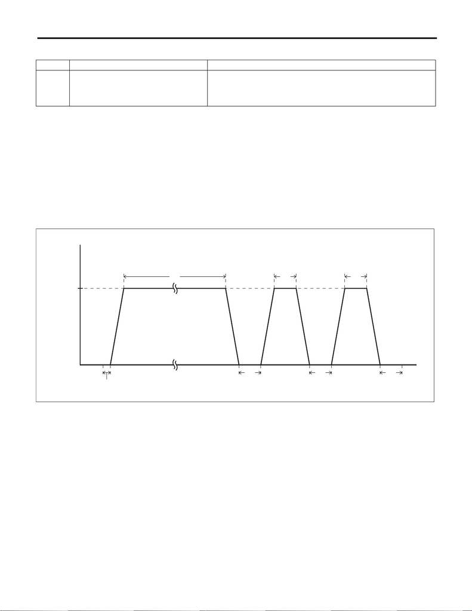

EN(STI)(diag)-53

Drive Cycle

ENGINE (DIAGNOSTICS)

6. DRIVE CYCLE F

Diagnostic procedure:

1) With the ignition switch ON (engine stopped), read the value in «Coolant Temp.» and «Intake Air Temp.».

<Ref. to EN(STI)(diag)-36, DISPLAY CURRENT ENGINE DATA (NORMAL MODE), OPERATION, Subaru

Select Monitor.>

2) If the values from step 1) satisfy the following conditions, idle the engine for two minutes or more.

Condition:

|Engine coolant temperature — Intake air temperature|

≤

5°C (9°F)

NOTE:

• If the conditions are not satisfied, turn the ignition switch to OFF and wait until the parameters are satisfied.

• Do not move the shift lever from neutral position during idling.

3) Drive according to the drive pattern described below.

DTC Item Condition

P0111

Intake Air Temperature Sensor Range/Per-

formance Problem

• At least 6 hours must have elapsed since the ignition switch was

turned OFF under a completely warmed up condition.

• For models with block heater, at least 6 hours must have elapsed with-

out operating the block heater.

(A) Vehicle speed (B) Elapsed time

(1) Idle the engine for 2 minutes or

more.

(4) Drive for 30 seconds or more at a

constant speed of 80 km/h (50

MPH) or more.

(6) Drive for 30 seconds or more at a

constant speed of 80 km/h (50

MPH) or more.

(2) Drive for a total period of 15 min-

utes or more at a speed of 80 km/h

(50 MPH) or more.

(5) Stop the vehicle and idle for 30

seconds or more.

(7) Stop the vehicle and idle for 30 sec-

onds.

(3) Stop the vehicle and idle for 30

seconds or more.

(A)

(B)

0

80 km/h

(50 MPH)

EN-07588

(1)

(4) (6)(2)

(3) (5) (7)

[figure not shown]

EN(STI)(diag)-54

Drive Cycle

ENGINE (DIAGNOSTICS)

NOTE:

• In pattern (2), it is acceptable to decelerate to less than 80 km/h (50 MPH) or to stop the vehicle depending

on the traffic conditions. Drive the vehicle at 80 km/h (50 MPH) or more until the total driving time reaches or

exceeds 15 minutes.

• There is no given transition time between idling and cruising.

• Driving at constant speed only on a downhill causes smaller engine load and may result in failure to obtain

a right diagnostic result.

• If the ignition switch is turned to OFF during driving cycle F, perform this driving cycle again after satisfying

the conditions listed in the table.

4) Read the temporary code using the Subaru Select Monitor or general scan tool. <Ref. to EN(STI)(diag)-

42, OPERATION, Read Diagnostic Trouble Code (DTC).>

7. DRIVE CYCLE G

Diagnostic procedure:

1) Disconnect the battery negative terminal, and reconnect after at least 10 seconds have passed.

2) Idle the engine until engine coolant temperature is 80°C (176°F) more.

3) Stop the engine to decrease the engine coolant temperature down to 40°C (104°F) or less.

NOTE:

Do not let engine coolant temperature drop to 5°C (41°F) or less.

4) Idle the engine until engine coolant temperature is 80°C (176°F) more.

5) Stop the engine to decrease the engine coolant temperature down to 40°C (104°F) or less.

NOTE:

Do not let engine coolant temperature drop to 5°C (41°F) or less.

6) Idle the engine.

7) Read the temporary code using the Subaru Select Monitor or general scan tool. <Ref. to EN(STI)(diag)-

42, OPERATION, Read Diagnostic Trouble Code (DTC).>

DTC Item Condition

P0410 Secondary Air Injection System —

P0411 Secondary Air Injection System Incorrect Flow Detected —

P0414 Secondary Air Injection System Switching Valve “A” Circuit Shorted —

P0417 Secondary Air Injection System Switching Valve “B” Circuit Shorted —

P1410 Secondary Air Injection System Switching Valve Stuck Open —

P2258 Air System Control "A" Circuit High —

P2440 Secondary Air Injection System Switching Valve Stuck Open (Bank1) —

P2441 Secondary Air Injection System Switching Valve Stuck Closed (Bank1) —

P2442 Secondary Air Injection System Switching Valve Stuck Open (Bank2) —

P2443 Secondary Air Injection System Switching Valve Stuck Closed (Bank2) —

[figure not shown]

EN(STI)(diag)-55

Drive Cycle

ENGINE (DIAGNOSTICS)

8. DRIVE CYCLE H

Diagnostic procedure:

1) With the ignition switch ON (engine stopped), read the value in «Coolant Temp.» and «Intake Air Temp.».

<Ref. to EN(STI)(diag)-36, DISPLAY CURRENT ENGINE DATA (NORMAL MODE), OPERATION, Subaru

Select Monitor.>

2) If the values from step 1) satisfy the following conditions, idle the engine for two minutes or more.

Condition:

|Engine coolant temperature — Intake air temperature|

≤

5°C (9°F)

NOTE:

• If the conditions are not satisfied, turn the ignition switch to OFF and wait until the parameters are satisfied.

• Do not move the shift lever from neutral position during idling.

3) Read the temporary code using the Subaru Select Monitor or general scan tool. <Ref. to EN(STI)(diag)-

42, OPERATION, Read Diagnostic Trouble Code (DTC).>

DTC Item Condition

P0071

Ambient Temperature Sensor Circuit "A"

Range/Performance

• At least 6 hours must have elapsed since the ignition switch was

turned OFF under a completely warmed up condition.

• For models with block heater, at least 6 hours must have elapsed with-

out operating the block heater.

P0116

Engine Coolant Temperature Sensor 1 Cir-

cuit Range/Performance

• At least 6 hours must have elapsed since the ignition switch was

turned OFF under a completely warmed up condition.

• For models with block heater, at least 6 hours must have elapsed with-

out operating the block heater.

P0451

Evaporative Emission System Pressure

Sensor/Switch Range/Performance

At least 60 seconds must have elapsed since the ignition switch was

turned OFF.

P050A

Cold Start Idle Air Control System Perfor-

mance

—

P050B Cold Start Ignition Timing Performance —

P2431

Secondary Air Injection System Air Flow /

Pressure Sensor Circuit Range/Perfor-

mance

—

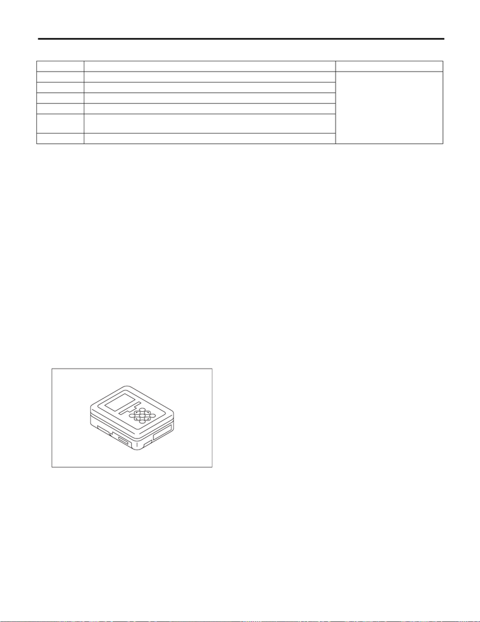

EN(STI)(diag)-56

Drive Cycle

ENGINE (DIAGNOSTICS)

9. DRIVE CYCLE I

CAUTION:

Be careful of the state of the battery when performing the drive cycle I consecutively. Performing the

drive cycle I consecutively without the engine running may cause a low battery voltage and battery

discharge.

NOTE:

• If it is necessary to perform drive cycle I consecutively, drive the vehicle under the following conditions to

release accumulated evaporating gas. Performing the drive cycle I consecutively without starting the engine

causes a large amount of evaporating gas to accumulate in the canister, which hinders an accurate diagno-

sis.

• After engine is warmed up.

• Drive for 10 minutes or more at a speed of 48 km/h (30 MPH) or more (duration of drive can be an ac-

cumulation)

• To obtain an accurate diagnostic result, perform the procedures according to the following points.

• Do not refuel gas immediately before performing drive cycle I. There will be a large amount of evapo-

rating gas immediately after refuel, which may cause a less accurate diagnostic performance.

• Do not shake the vehicle while performing drive cycle I. Shaking the vehicle causes evaporating gas to

increase inside the fuel tank, which may cause a less accurate diagnostic performance.

• Do not perform any service operation including installation or removal of parts or connectors while per-

forming drive cycle I. Performing service operation could affect on the functions of related parts, which may

cause a less accurate diagnostic performance.

1) Prepare the Subaru Select Monitor kit. <Ref. to EN(STI)(diag)-7, PREPARATION TOOL, General De-

scription.>

2) Prepare PC with Subaru Select Monitor installed.

3) Connect the USB cable to SDI (Subaru Diagnosis Interface) and USB port on the personal computer (ded-

icated port for the Subaru Select Monitor).

NOTE:

The dedicated port for the Subaru Select Monitor means the USB port which was used to install the Subaru

Select Monitor.

4) Connect the diagnosis cable to SDI.

DTC Item Condition

P0455 Evaporative Emission System Leak Detected (Large Leak)

«Coolant Temp.»: 5 — 45°C (41

— 113°F)

«Intake Air Temp.»: 5 — 50°C

(41 — 122°F)

P0456 Evaporative Emission Control System Leak Detected (Very Small Leak)

P2402 Evaporative Emission System Leak Detection Pump Control Circuit High

P2404

Evaporative Emission System Leak Detection Pump Sense Circuit Range/Per-

formance

P2420 Evaporative Emission System Switching Valve Control Circuit High

EN-05692

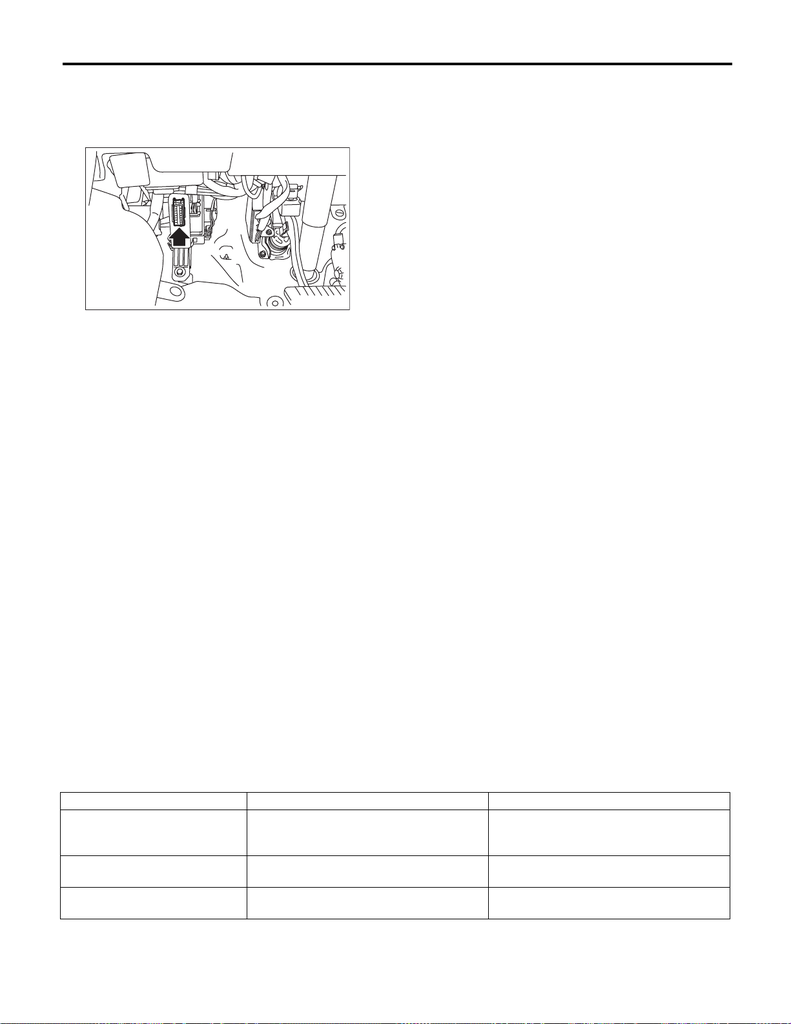

EN(STI)(diag)-57

Drive Cycle

ENGINE (DIAGNOSTICS)

5) Connect SDI to data link connector located in the lower portion of the instrument panel (on the driver’s

side).

CAUTION:

Do not connect the scan tools except for Subaru Select Monitor and general scan tool.

6) Start the PC.

7) Turn the ignition switch to ON (engine OFF) and run the “PC application for Subaru Select Monitor”.

8) On «Main Menu» display, select {Each System Check}.

9) On «System Selection Menu» display, select {Engine Control System}.

10) Click the [OK] button after the information of engine type has been displayed.

11) On «Engine Diagnosis» display, select {OBD System}.

12) On «OBD Menu» display, select {Evaporative System Leak Test}.

13) On «Evaporative System Leak Test» display, select {Evaporative System Leak Test}.

14) On «Evaporative System Leak Test is running. Press Cancel to exit this function.» display, click the [OK]

button to perform evaporative system leak test.

15) When «Conditions have been enabled to control this function. Turn the ignition switch off to terminate the

test.» display appears, wait for 30 minutes without clicking the [OK] button.

CAUTION:

Do not leave the vehicle for an extended period of time after the test is complete. This may cause ear-

ly deterioration of the battery or discharged battery.

NOTE:

• Clicking the [OK] button bring the «Evaporative System Leak Test» display back, although the test is con-

tinuing.

• The Subaru Select Monitor screen does not change after the evaporative system leak test is complete or

when the test is aborted by turning off the ignition switch.

• If «Test conditions are not correct» display appears, check that the values in «Coolant Temp.» and «Intake

Air Temp.» are within the specified range using Subaru Select Monitor. If the conditions are satisfied, make

the necessary preparation for the drive cycle again. <Ref. to EN(STI)(diag)-49, PREPARATION FOR DRIVE

CYCLE, PROCEDURE, Drive Cycle.>

16) After 30 minutes passed from the start of step 14), click the [OK] button to return to the «Evaporative Sys-

tem Leak Test» display.

17) Click buttons until the «OBD Menu» display appears, then select {Result of on-board monitor test}.

18) In the {Result of on-board monitor test}, check TID $C1 — $CA of MID $3C.

EN-09145

Result of on-board monitor test

Display Details Note

$0000 is stored in all Val.

During the evaporative system leak test, the

test conditions were not met and the test was

canceled.

Once the test conditions are met, perform the

test again.

All Val. are stored with values and

OK is set to all the results.

Evaporative system leak test is completed

correctly.

While the ignition switch is ON, read tempo-

rary codes using the Subaru Select Monitor.

Some results were no good.

The evaporative system leak test completed

successfully but the results were faulty.

While the ignition switch is ON, read tempo-

rary codes using the Subaru Select Monitor.

[figure not shown]

EN(STI)(diag)-58

Drive Cycle

ENGINE (DIAGNOSTICS)

19) When the evaporative system leak test is completed correctly, read the temporary codes with the ignition

switch turned to ON position. If the DTC is recorded, check the appropriate DTC. <Ref. to EN(STI)(diag)-42,

OPERATION, Read Diagnostic Trouble Code (DTC).>

NOTE:

The temporary code will be cleared by turning ignition switch to OFF.

10.DRIVE CYCLE J

1) Idle the engine for 15 minutes or more.

2) Turn the ignition switch to OFF.

3) After 10 hours passed from the start of step 2), read the temporary code using the Subaru Select Monitor.

<Ref. to EN(STI)(diag)-42, OPERATION, Read Diagnostic Trouble Code (DTC).>

DTC Item Condition

P2610 ECM/PCM Internal Engine Off Timer Performance —